# How Transmission Type ‘Automatic’ or ‘Manual’ affect MPG

Oye Akinnikawe

January 17, 2017

## Data Analysis

first we will load the required libraries and data, then we will take a quick peek at the data.

```r
library(ggplot2)
data(mtcars)
head(mtcars)
```

```
##                    mpg cyl disp  hp drat    wt  qsec vs am gear carb
## Mazda RX4         21.0   6  160 110 3.90 2.620 16.46  0  1    4    4
## Mazda RX4 Wag     21.0   6  160 110 3.90 2.875 17.02  0  1    4    4
## Datsun 710        22.8   4  108  93 3.85 2.320 18.61  1  1    4    1
## Hornet 4 Drive    21.4   6  258 110 3.08 3.215 19.44  1  0    3    1
## Hornet Sportabout 18.7   8  360 175 3.15 3.440 17.02  0  0    3    2
## Valiant           18.1   6  225 105 2.76 3.460 20.22  1  0    3    1
```

We need to transform some of the variables in *mtcars* into factors. This will help in data exploration (shown in boxplot in Appendix) and obtaining better models during regression analysis.

```r
mtcars$cyl <- factor(mtcars$cyl)
mtcars$am <- factor(mtcars$am,labels=c("Automatic","Manual"))
```

Get the mean for the factors of *am* i.e automatic and manual

```r
aggregate(mpg~am, data = mtcars, mean)
```

```
##          am      mpg
## 1 Automatic 17.14737
## 2    Manual 24.39231
```

Thus, we will use the hypothesies that manual cars have a **7.25 MPG** higher than automatic cars.

Split the variable *am* into “auto” and “manual”

```r
auto <- mtcars[mtcars$am == "Automatic",]
manual <- mtcars[mtcars$am == "Manual",]
```

We perform a t.test to see if there is a significant difference between the mean *mpg* for automatic and manual cars

```r
t.test(auto$mpg,manual$mpg)
```

```
##
##  Welch Two Sample t-test
##
## data:  auto$mpg and manual$mpg
## t = -3.7671, df = 18.332, p-value = 0.001374
## alternative hypothesis: true difference in means is not equal to 0
## 95 percent confidence interval:
##  -11.280194  -3.209684
## sample estimates:
## mean of x mean of y
##  17.14737  24.39231
```

The p-value of 0.001374 states that there is a significant difference in the mpg values for automatic and manual cars. we have to quantify this using regression models.

We will perform an initial linear fit for mpg~am, then we will add more variables to the regression to see if other variables have an effect on our model.

```r
## perform initial lm fit for mpg~am
fit1 <- lm(mpg ~ am, data = mtcars)
summary(fit1)
```

```
##
## Call:
## lm(formula = mpg ~ am, data = mtcars)
##
## Residuals:
##     Min      1Q  Median      3Q     Max
## -9.3923 -3.0923 -0.2974  3.2439  9.5077
##
## Coefficients:
##             Estimate Std. Error t value Pr(>|t|)
## (Intercept)   17.147      1.125  15.247 1.13e-15 ***
## amManual       7.245      1.764   4.106 0.000285 ***
## ---
## Signif. codes:  0 '***' 0.001 '**' 0.01 '*' 0.05 '.' 0.1 ' ' 1
##
## Residual standard error: 4.902 on 30 degrees of freedom
## Multiple R-squared:  0.3598, Adjusted R-squared:  0.3385
## F-statistic: 16.86 on 1 and 30 DF,  p-value: 0.000285
```

The initial model shows that mean *mpg* for automatic cars is 17.15 MPG while that of manual cars is 7.25 MPG higher. The R<sup>2</sup> value of 0.36 shows that only 36% of the total variability is explained by our model. We need to try using multivariate linear regression to better fit our model.

```r
## perform fit2 by adding other variables
fit2 <- lm(mpg ~ am + cyl + disp, data = mtcars)
```

```r
## perform fit3 by adding more variables
fit3 <- lm(mpg ~ am + cyl + disp + hp + wt, data = mtcars)
```

Next, we perform an analysis of variance to see if the second and third model fits were necessary

```r
#$Analysis of Variance
anova(fit1, fit2, fit3)
```

```
## Analysis of Variance Table
##
## Model 1: mpg ~ am
## Model 2: mpg ~ am + cyl + disp
## Model 3: mpg ~ am + cyl + disp + hp + wt
##   Res.Df    RSS Df Sum of Sq       F    Pr(>F)
## 1     30 720.90
## 2     27 230.46  3    490.44 27.1724 4.919e-08 ***
## 3     25 150.41  2     80.05  6.6528  0.004825 **
## ---
## Signif. codes:  0 '***' 0.001 '**' 0.01 '*' 0.05 '.' 0.1 ' ' 1
```

```r
summary(fit3)
```

```
##
## Call:
## lm(formula = mpg ~ am + cyl + disp + hp + wt, data = mtcars)
##
## Residuals:
##     Min      1Q  Median      3Q     Max
## -3.9374 -1.3347 -0.3903  1.1910  5.0757
##
## Coefficients:
##              Estimate Std. Error t value Pr(>|t|)
## (Intercept) 33.864276   2.695416  12.564 2.67e-12 ***
## amManual     1.806099   1.421079   1.271   0.2155
## cyl6        -3.136067   1.469090  -2.135   0.0428 *
## cyl8        -2.717781   2.898149  -0.938   0.3573
## disp         0.004088   0.012767   0.320   0.7515
## hp          -0.032480   0.013983  -2.323   0.0286 *
## wt          -2.738695   1.175978  -2.329   0.0282 *
## ---
## Signif. codes:  0 '***' 0.001 '**' 0.01 '*' 0.05 '.' 0.1 ' ' 1
##
## Residual standard error: 2.453 on 25 degrees of freedom
## Multiple R-squared:  0.8664, Adjusted R-squared:  0.8344
## F-statistic: 27.03 on 6 and 25 DF,  p-value: 8.861e-10
```

The selected model *fit3* explains 87% of the total variability in our model. The addition of *cyl*, *disp*, *hp*, and *wt* affected the correlation between *mpg* and *am*. From our model, the difference between automatic and manual transmission is **1.81 MPG**

## Appendix

The appendix shows some of the exploratory data analysis that was performed. Plot 1 shows the box plot of mpg vs transmission type, Plot 2 shows a pairs plot for selected variables, and plot 3 shows the residual plot used for investigating model fit.

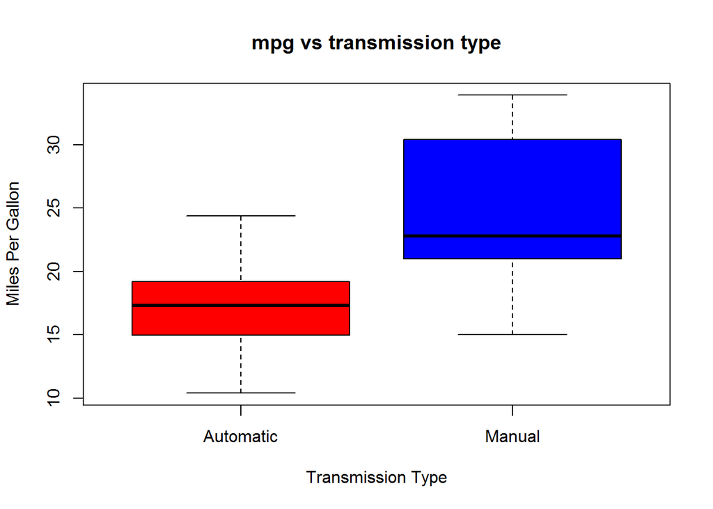

```r
boxplot(mpg ~ am, data = mtcars, ylab = "Miles Per Gallon",
        xlab = "Transmission Type", main = "mpg vs transmission type",
        col = (c("red","blue")))
```

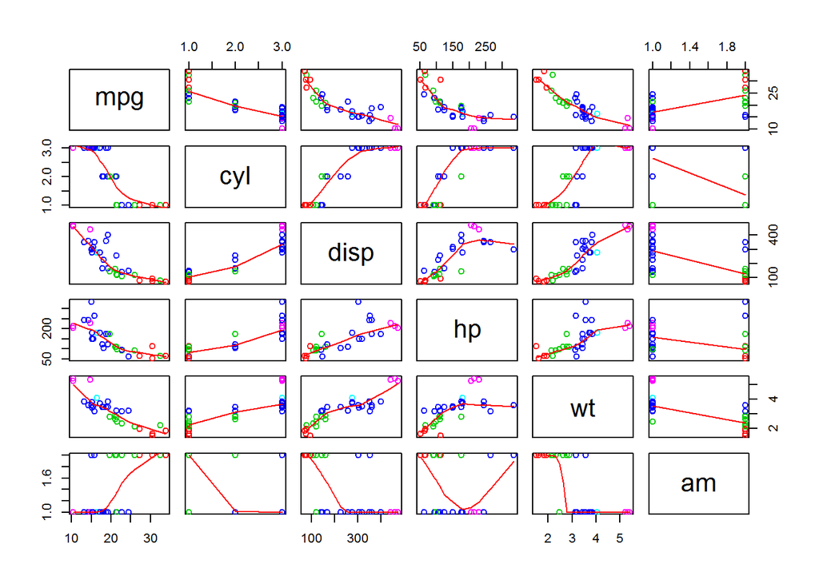

```r
#Pairs plot
mtcars_vars <- mtcars[, c(1,2,3,4,6,9)]
par(mar = c(1,1,1,1))
pairs(mtcars_vars, panel = panel.smooth, col = mtcars$wt + 1)
```

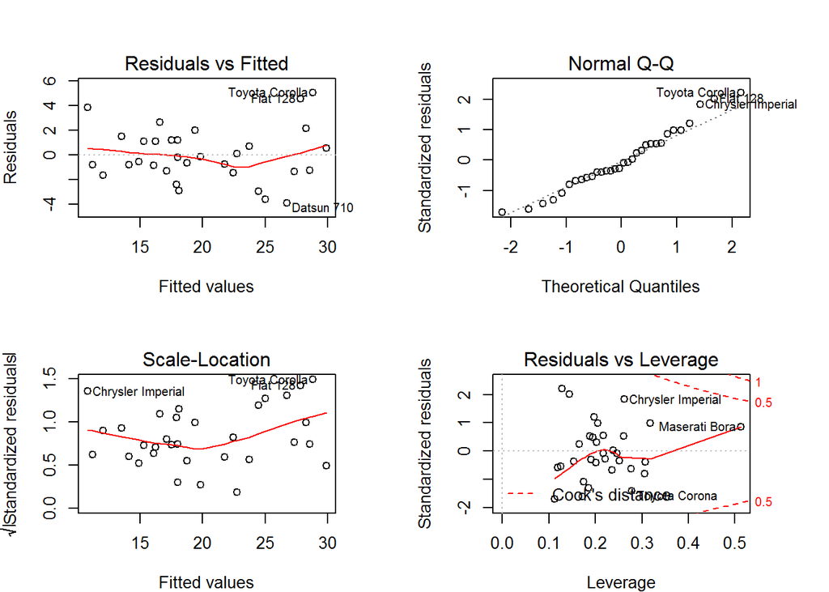

```r
##residual plot
par(mar = c(4,4,4,4))
par(mfrow=c(2,2))
plot(fit3)
```